# Tipologia y ciclo de vida de los datos: PRAC2 - integración, limpieza, validación y análisis

Autor: Leidy Liliana Torres Bolívar & Jose Carlos Sola Verdú

Diciembre 2020

# 1 Descripción del dataset. ¿Por qué es importante y qué pregunta/problema pretende responder?

Para la realización de este ejercicio se usará un conjunto de datos que contiene los clientes de un distribuidor mayorista. Incluye el gasto anual en unidades monetarias (mu) en diversas categorías de productos (Lacteos, carnes, congelados ETC) Se evidencia que son datos que se pueden trabajar en problemas no supervisados con métodos de agregación (clusters) ya que no cuentan con una categorización o clase.

Fuente. https://www.kaggle.com/binovi/wholesale-customers-data-set

# 2 Integración y selección de los datos de interés a analizar.

```r
# Como primer paso se llaman las librerias necesarias para el ejercicio

library(ggplot2)
library(dplyr)
library(dummies)
library(kableExtra)
library(scales)
library(cluster)
library(factoextra)
library(NbClust)
library(arules)
library(fpc)
```

```r
#Se carga el conjunto de datos el cual contiene los nombres de sus atributos.

customers_data<-read.csv("https://archive.ics.uci.edu/ml/machine-learning-databases/00292/Wholesale%20customers%20data.csv", header=T, sep=",")
attach(customers_data)

#Visualizamos el data frame
head(customers_data)
```

```
##   Channel Region Fresh Milk Grocery Frozen Detergents_Paper Delicassen
## 1       2      3 12669 9656    7561    214             2674       1338
## 2       2      3  7057 9810    9568   1762             3293       1776
## 3       2      3  6353 8808    7684   2405             3516       7844
## 4       1      3 13265 1196    4221   6404              507       1788
## 5       2      3 22615 5410    7198   3915             1777       5185
## 6       2      3  9413 8259    5126    666             1795       1451
```

Descripción de las diferentes variables:

FRESH: annual spending (m.u.) on fresh products (Continuous)

MILK: annual spending (m.u.) on milk products (Continuous)

GROCERY: annual spending (m.u.)on grocery products (Continuous)

FROZEN: annual spending (m.u.)on frozen products (Continuous)

DETERGENTS_PAPER: annual spending (m.u.) on detergents and paper products (Continuous)

DELICATESSEN: annual spending (m.u.)on and delicatessen products (Continuous)

CHANNEL: 1=Horeca 2=Retail

REGION: 1=Lisnon, 2=Oporto or 3=Other

```r
#Se valida la estructura de los datos
 str(customers_data)
```

```
## 'data.frame':    440 obs. of  8 variables:
##  $ Channel         : int  2 2 2 1 2 2 2 2 1 2 ...
##  $ Region          : int  3 3 3 3 3 3 3 3 3 3 ...
##  $ Fresh           : int  12669 7057 6353 13265 22615 9413 12126 7579 5963 6006 ...
##  $ Milk            : int  9656 9810 8808 1196 5410 8259 3199 4956 3648 11093 ...
##  $ Grocery         : int  7561 9568 7684 4221 7198 5126 6975 9426 6192 18881 ...
##  $ Frozen          : int  214 1762 2405 6404 3915 666 480 1669 425 1159 ...
##  $ Detergents_Paper: int  2674 3293 3516 507 1777 1795 3140 3321 1716 7425 ...
##  $ Delicassen      : int  1338 1776 7844 1788 5185 1451 545 2566 750 2098 ...
```

# 3 Limpieza de los datos.

## 3.1 ¿Los datos contienen ceros o elementos vacíos? ¿Cómo gestionarías cada uno de estos casos?

```r
#Se valida que no existan valores vacios
colSums(is.na(customers_data))
```

```
##          Channel           Region            Fresh             Milk
##                0                0                0                0
##          Grocery           Frozen Detergents_Paper       Delicassen
##                0                0                0                0
```

Se evidencia que el set de datos no contempla valores vacíos, si embargo en caso de tener valores vacios en valores contunios se usaria la media de conjunto de datos para completa dicha información.

## 3.2 Identificación y tratamiento de valores extremos.

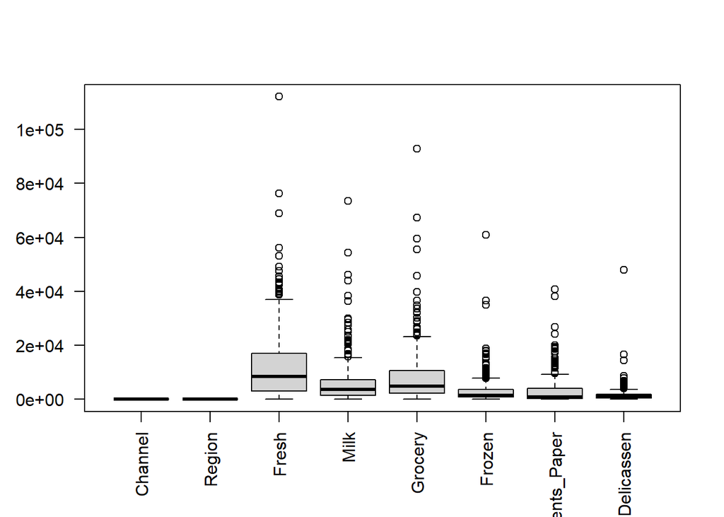

```r
#Se hace validación de Outliers por medio de la gráfica boxplot para cada una de las variables
boxplot(customers_data,las=2)
```

Como se observa hay Outliers en las medidas Fresh,Milk,Grocery,Frozen,Detergents_Paper,Delicassen lo cual podría claramente la clasificación de los datos, por eso se descartarán usando la diferencia de los percentiles 25 y 75 y calculando el IQR (Rango intercuatilico) para encontrar los rangos y descartar valore atipicos.

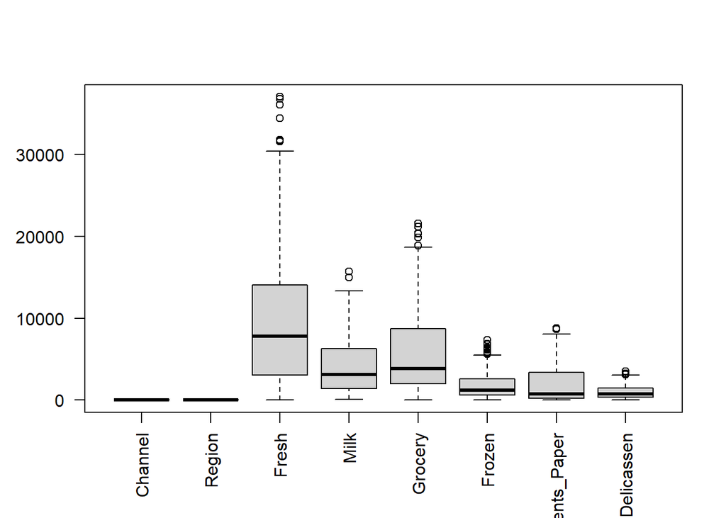

```r
#Quitando datos atípicos de las variables Fresh,Milk,Grocery,Frozen,Detergents_Paper,Delicassen almacenandola en el df customers_data2
customers_data2 <- customers_data
for (x in colnames(customers_data2[3:8])){
  qt <- quantile(customers_data[[x]], probs=c(.25, .75), na.rm = FALSE)
  iqr <- IQR(customers_data2[[x]])
  superior <-  qt[2]+1.5*iqr
  inferior<- qt[1]-1.5*iqr
  customers_data2<- subset(customers_data2, customers_data2[[x]] > (qt[1] - 1.5*iqr) & customers_data2[[x]] < (qt[2]+1.5*iqr))
}
#Se grafica nuevamente los valores atipicos usando el nuevo df
boxplot(customers_data2, las=2)
```

Comparando las dos graficas se observa que el número de valores atipicos bajó considerablente respecto al DF original, esto sin duda ayudará a mejorar el rendieminto del modelo de agregación.

```r
#Normalización de datos para manejar la misma escala en las diferentes variables
customers_data_scale <- scale(customers_data2)
head(customers_data_scale)
```

```
##      Channel   Region       Fresh       Milk    Grocery      Frozen
## 1  1.6065098 0.576818  0.36757080  1.6490562  0.3811910 -0.97640156
## 2  1.6065098 0.576818 -0.31831375  1.6947119  0.7958942 -0.02850308
## 4 -0.6205403 0.576818  0.44041242 -0.8590425 -0.3089478  2.81396769
## 6  1.6065098 0.576818 -0.03036934  1.2348938 -0.1219491 -0.69962500
## 7  1.6065098 0.576818  0.30120670 -0.2652220  0.2601068 -0.81351978
## 8  1.6065098 0.576818 -0.25451622  0.2556680  0.7665530 -0.08545047
##   Detergents_Paper Delicassen
## 1       0.33835403  0.4390311
## 2       0.60961495  0.9896503
## 4      -0.61127831  1.0047357
## 6      -0.04684524  0.5810858
## 7       0.54256662 -0.5578661
## 8       0.62188524  1.9827761
```

# 4 Análisis de los datos.

## 4.1 Selección de los grupos de datos que se quieren analizar/comparar (planificación de los análisis a aplicar).

En primer lugar, se realizará un resumen estadístico sobre las variables que se van a utilizar:

```r
summary(customers_data)
```

```
##     Channel          Region          Fresh             Milk
##  Min.   :1.000   Min.   :1.000   Min.   :     3   Min.   :   55
##  1st Qu.:1.000   1st Qu.:2.000   1st Qu.:  3128   1st Qu.: 1533
##  Median :1.000   Median :3.000   Median :  8504   Median : 3627
##  Mean   :1.323   Mean   :2.543   Mean   : 12000   Mean   : 5796
##  3rd Qu.:2.000   3rd Qu.:3.000   3rd Qu.: 16934   3rd Qu.: 7190
##  Max.   :2.000   Max.   :3.000   Max.   :112151   Max.   :73498
##     Grocery          Frozen        Detergents_Paper    Delicassen
##  Min.   :    3   Min.   :   25.0   Min.   :    3.0   Min.   :    3.0
##  1st Qu.: 2153   1st Qu.:  742.2   1st Qu.:  256.8   1st Qu.:  408.2
##  Median : 4756   Median : 1526.0   Median :  816.5   Median :  965.5
##  Mean   : 7951   Mean   : 3071.9   Mean   : 2881.5   Mean   : 1524.9
##  3rd Qu.:10656   3rd Qu.: 3554.2   3rd Qu.: 3922.0   3rd Qu.: 1820.2
##  Max.   :92780   Max.   :60869.0   Max.   :40827.0   Max.   :47943.0
```

Seguidamente, se seleccionaran los grupos del conjunto de datos que pueden resultar interesantes para analizar/comparar:

```r
# Agrupación por la Región dónde se han vendido los productos (variable Region)

customers_data.Vendido_en_Lisboa <- customers_data[customers_data$Region == "1",]
customers_data.Vendido_en_Oporto <- customers_data[customers_data$Region == "2",]
customers_data.Vendido_en_Otros <- customers_data[customers_data$Region == "3",]


# Agrupación por Ventas al por Mayor o al por Menor (variable Channel)

customers_data.porMayor <- customers_data[customers_data$Channel == "1",]
customers_data.porMenor <- customers_data[customers_data$Channel == "2",]
```

Una vez terminada la fase de análisis y preparación de los datos. En esta fase se usaran diferentes métodos para identificar el número de clusters más óptimo, Se usará el metodo de la silueta media,

## 4.2 Comprobación de la normalidad y homogeneidad de la varianza.

Para la comprobación de que los valores de las variables cuantitativas están distribuidas normalmente, se hará uso de la prueba de normalidad de Anderson-Darling.

De esta forma se comprueba que cada variable obtiene un p_valor superior a alpha = 0.05. Si se cumple esta condición, se considerará que una determinada variable sigue una distribución normal.

```r
library (nortest)

alpha = 0.05

col.names = colnames (customers_data)

for (j in 1:ncol (customers_data)) {
  if (j == 1) cat ("Variables que no siguen una distribución normal:\n")
  if (is.integer (customers_data [ , j]) | is.numeric (customers_data [ , j])) {
    p_val = ad.test (customers_data [ , j]) $p.value
    if (p_val < alpha) {
      cat (col.names[j])

      # Format output
      if (j < ncol (customers_data) - 1) cat (", ")
      if (j %% 3 == 0) cat ("\n")
    }
  }
}
```

```
## Variables que no siguen una distribución normal:
## Channel, Region, Fresh,
## Milk, Grocery, Frozen,
## Detergents_PaperDelicassen
```

El siguiente paso será comprobar la homogeinidad de varianzas. Para ello, se utilizará la aplicación de test de Fligner-Killeen. Se estudiará la homogeinidad entre diferentes grupos formados por la region y el tipo de venta (channel). También se puede estudiar la homogeinidad entre las distintas variables del tipo de alimentos.

```r
fligner.test(Channel ~ Region, data = customers_data)
```

```
##
##  Fligner-Killeen test of homogeneity of variances
##
## data:  Channel by Region
## Fligner-Killeen:med chi-squared = 4.3393, df = 2, p-value = 0.1142
```

```r
fligner.test(Fresh ~ Milk, data = customers_data)
```

```
##
##  Fligner-Killeen test of homogeneity of variances
##
## data:  Fresh by Milk
## Fligner-Killeen:med chi-squared = 439, df = 420, p-value = 0.2518
```

```r
fligner.test(Grocery ~ Frozen, data = customers_data)
```

```
##
##  Fligner-Killeen test of homogeneity of variances
##
## data:  Grocery by Frozen
## Fligner-Killeen:med chi-squared = 439, df = 425, p-value = 0.3093
```

```r
fligner.test(Detergents_Paper ~ Delicassen, data = customers_data)
```

```
##
##  Fligner-Killeen test of homogeneity of variances
##
## data:  Detergents_Paper by Delicassen
## Fligner-Killeen:med chi-squared = 408.81, df = 402, p-value = 0.3965
```

Como se puede apreciar, todas las comparaciones superan el p_valor de 0.05, por lo que se entiende que la hipótesis de las varianzas son homogéneas.

## 4.3 Aplicación de pruebas estadísticas para comparar los grupos de dato y Representación de los resultados a partir de tablas y gráficas.

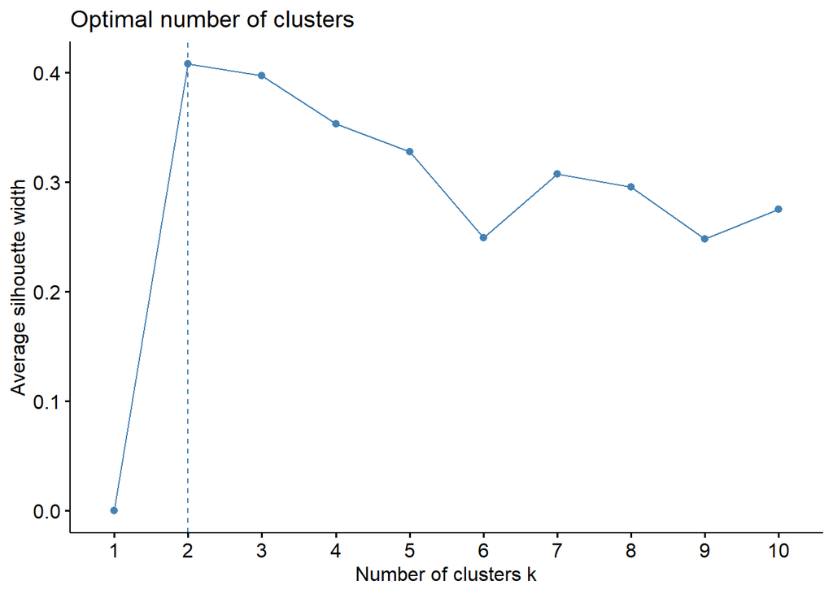

```r
#El método de la silueta media el cual mide la distancia de separación entre los clústers. Nos indica como de cerca está cada punto de un clúster a puntos de los clústers vecinos.

fviz_nbclust(customers_data2, kmeans, method="silhouette")
```

Según la grafica presentada anteriormente el mejor número de clusters serían k=2

Ahora usando el método wss de K-Means.

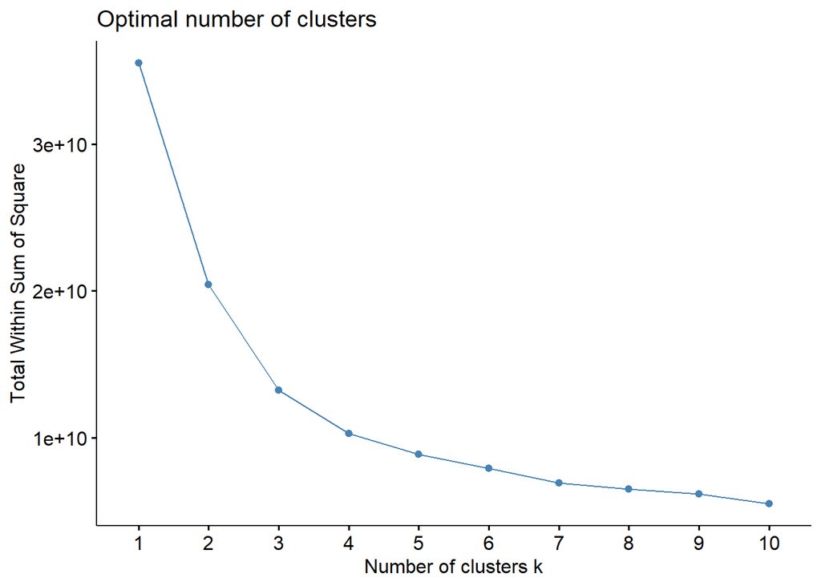

```r
#Ahora usando el método wss.
fviz_nbclust(customers_data2, kmeans, method="wss")
```

Al usar el metodo anterior se observa que la recomendación de clusters serían entre 3 y 4.

Ahora usamos la función kmeansruns del paquete fpc que ejecuta el algoritmo kmeans con un conjunto de valores, para después seleccionar el valor del número de clústers que mejor funcione de acuerdo a dos criterios: la silueta media (“asw”) y Calinski-Harabasz (“ch”). Usado en el ejercicio de ejemplo de la base de datos irs.

```r
fit_ch  <- kmeansruns(customers_data2, krange = 1:10, criterion = "ch")
fit_asw <- kmeansruns(customers_data2, krange = 1:10, criterion = "asw")

#asw la silueta media
fit_ch$bestk
```

```
## [1] 3
```

```r
#ch Calinski-Harabasz
fit_asw$bestk
```

```
## [1] 2
```

Según los resultados presentados anteriormente asw y ch recomiendan entre 2 y 3 clusters respectivamente.

Como los resultados del número de clusters estan entre dos y tres probaremos el algoritmo de K-Means con 2 y 3 para ver cual sería el más optimo

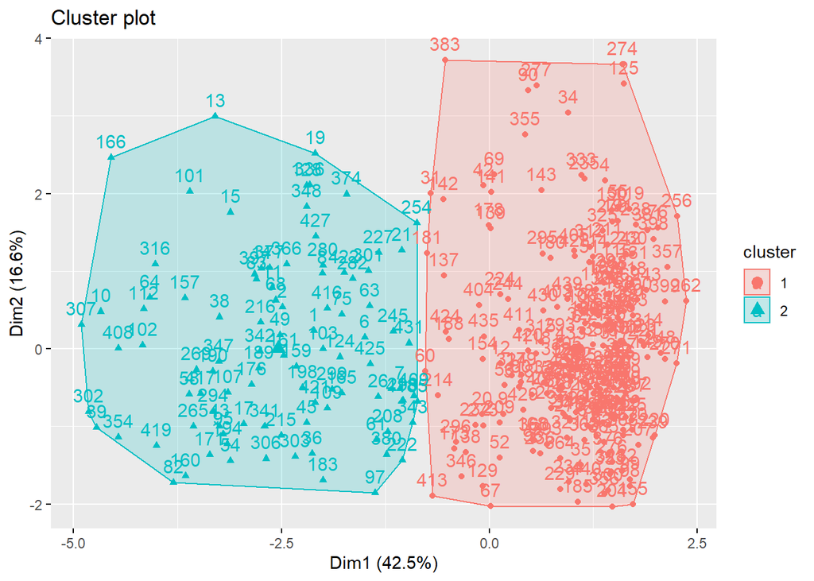

```r
#Con 2 clusters
k2_scale <- kmeans(customers_data_scale, 2)

#Graficamos los clusters generados con fviz_cluster
fviz_cluster(k2_scale, data = customers_data_scale)
```

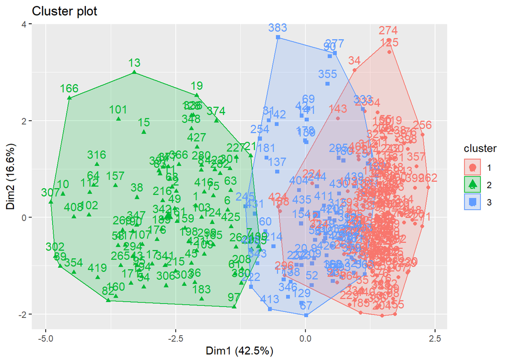

```r
#Con 3 clusters
k3_scale <- kmeans(customers_data_scale, 3)

#Graficamos los clusters generados con fviz_cluster
fviz_cluster(k3_scale, data = customers_data_scale)
```

Como se obderva en las gráficas generadas con fviz_cluster claramente el mejor número de clusters es 2 ya que se puede observar claramente la distinción entre los dos grupos, mientras que en la gráfica con 3 clusters hay algunos puntos que se solapan.

Ahora vamos a identificar las caracteristicas de cada uno de los clusters identificando de a dos variables la distribución de los dos clusters

```r
summary(customers_data2)
```

```
##     Channel          Region          Fresh            Milk
##  Min.   :1.000   Min.   :1.000   Min.   :    3   Min.   :   55
##  1st Qu.:1.000   1st Qu.:2.000   1st Qu.: 3026   1st Qu.: 1365
##  Median :1.000   Median :3.000   Median : 7769   Median : 3086
##  Mean   :1.279   Mean   :2.557   Mean   : 9661   Mean   : 4094
##  3rd Qu.:2.000   3rd Qu.:3.000   3rd Qu.:14070   3rd Qu.: 6248
##  Max.   :2.000   Max.   :3.000   Max.   :37036   Max.   :15729
##     Grocery          Frozen       Detergents_Paper   Delicassen
##  Min.   :    3   Min.   :  25.0   Min.   :   3.0   Min.   :   3.0
##  1st Qu.: 2003   1st Qu.: 575.5   1st Qu.: 229.5   1st Qu.: 353.5
##  Median : 3823   Median :1206.0   Median : 706.0   Median : 749.0
##  Mean   : 5716   Mean   :1808.5   Mean   :1901.9   Mean   : 988.8
##  3rd Qu.: 8699   3rd Qu.:2558.0   3rd Qu.:3379.5   3rd Qu.:1445.5
##  Max.   :21570   Max.   :7332.0   Max.   :8752.0   Max.   :3508.0
```

```r
k2 <- kmeans(customers_data2, 2)

k2
```

```
## K-means clustering with 2 clusters of sizes 228, 95
##
## Cluster means:
##    Channel   Region     Fresh     Milk  Grocery   Frozen Detergents_Paper
## 1 1.307018 2.561404  5283.417 4335.754 6031.583 1682.211         2198.873
## 2 1.210526 2.547368 20168.853 3512.474 4959.232 2111.758         1189.158
##   Delicassen
## 1   893.0965
## 2  1218.3684
##
## Clustering vector:
##   1   2   4   6   7   8   9  10  11  12  13  14  15  16  17  19  20  21  22  26
##   1   1   2   1   1   1   1   1   1   2   2   2   2   1   1   2   1   2   1   2
##  27  28  31  32  33  34  35  36  38  39  42  43  45  49  51  52  54  55  56  58
##   1   2   2   1   2   2   1   1   2   1   2   1   1   1   1   1   1   2   1   1
```

[output cut: 39 more lines]

```r
str(k2)
```

```
## List of 9
##  $ cluster     : Named int [1:323] 1 1 2 1 1 1 1 1 1 2 ...
##   ..- attr(*, "names")= chr [1:323] "1" "2" "4" "6" ...
##  $ centers     : num [1:2, 1:8] 1.31 1.21 2.56 2.55 5283.42 ...
##   ..- attr(*, "dimnames")=List of 2
##   .. ..$ : chr [1:2] "1" "2"
##   .. ..$ : chr [1:8] "Channel" "Region" "Fresh" "Milk" ...
##  $ totss       : num 3.55e+10
##  $ withinss    : num [1:2] 1.39e+10 6.57e+09
##  $ tot.withinss: num 2.04e+10
##  $ betweenss   : num 1.51e+10
##  $ size        : int [1:2] 228 95
##  $ iter        : int 1
##  $ ifault      : int 0
##  - attr(*, "class")= chr "kmeans"
```

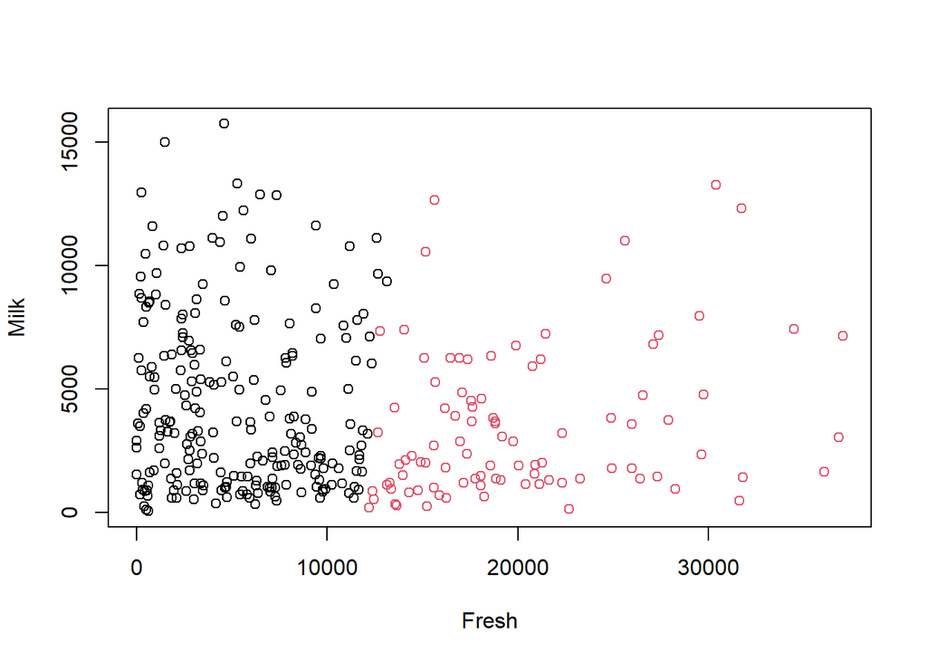

```r
#  Fresh y Milk
plot(customers_data2[c(3,4)], col=k2$cluster)
```

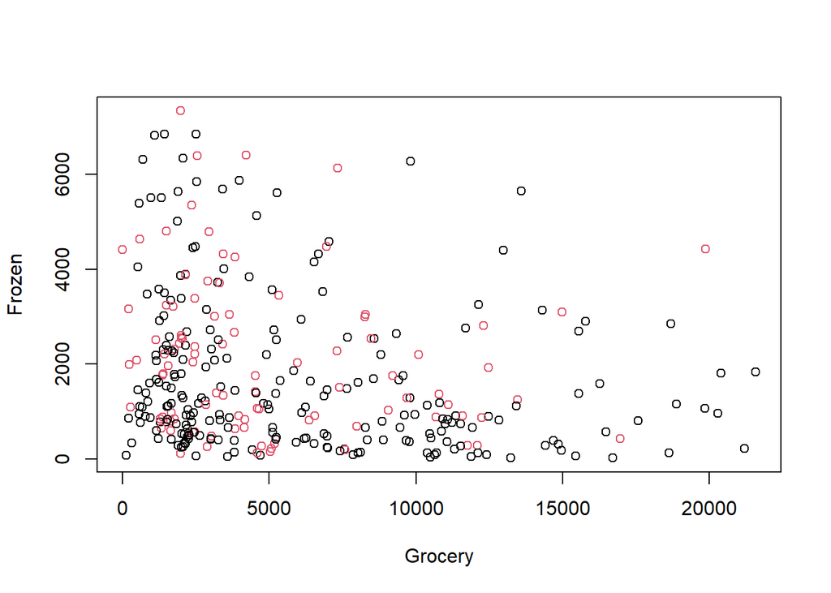

```r
# Grocery y Frozen
plot(customers_data2[c(5,6)], col=k2$cluster)
```

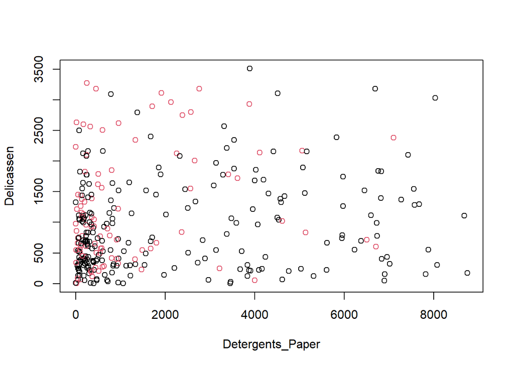

```r
# Detergents_Paper y Delicassen
plot(customers_data2[c(7,8)], col=k2$cluster)
```

Como se observa en la graficas presentadas anteriormente sólo se puede ver una distinción entre las variables Fresh y Milk, por eso se validara Fesh vs las demás

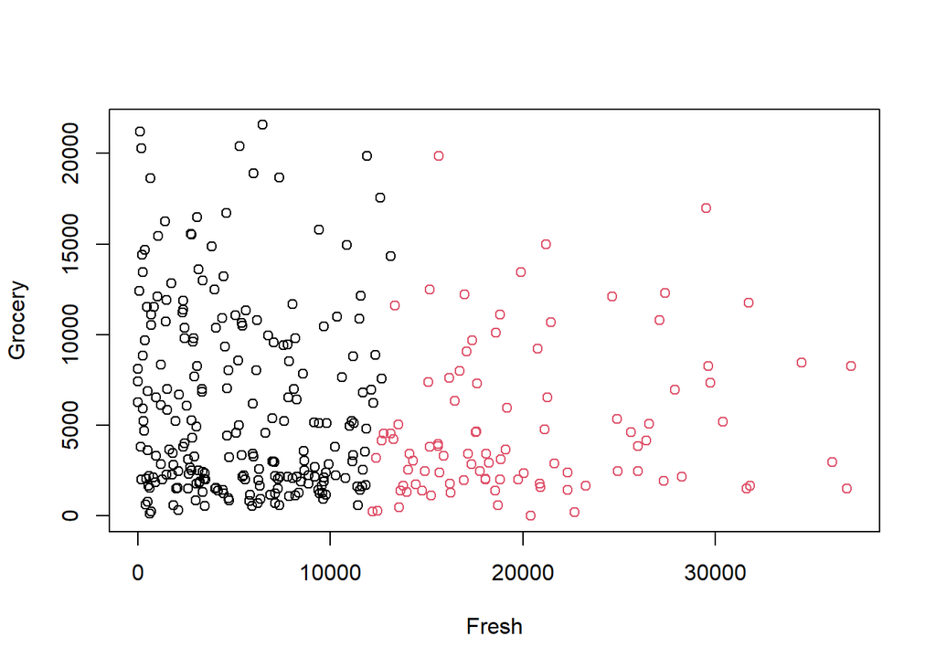

```r
 #  Fresh y Grocery
 plot(customers_data2[c(3,5)], col=k2$cluster)
```

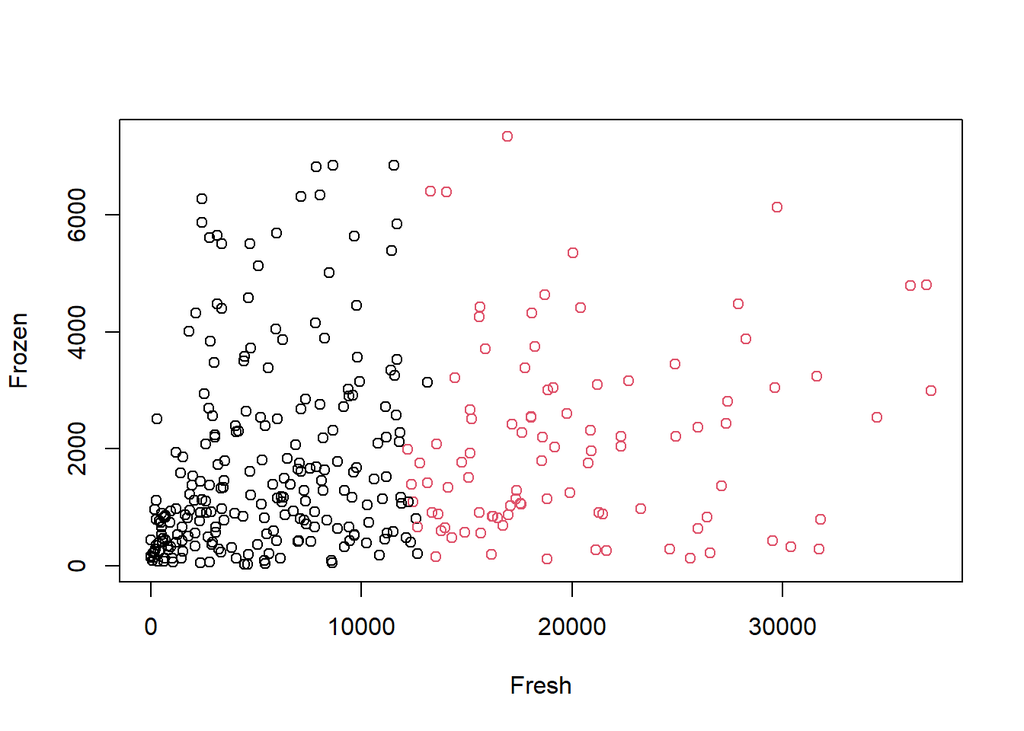

```r
# Fresh y Frozen
 plot(customers_data2[c(3,6)], col=k2$cluster)
```

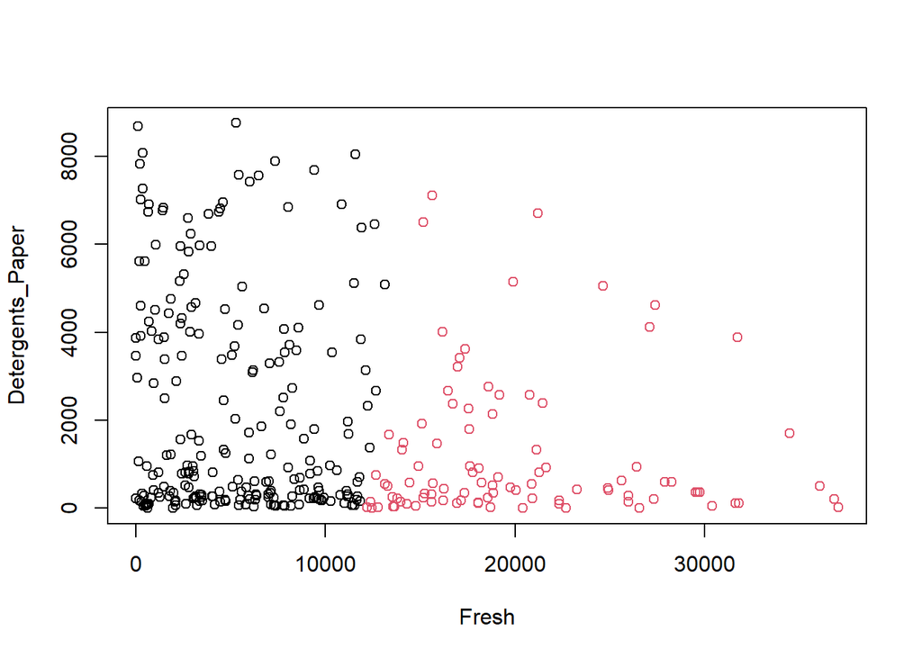

```r
# Fresh y Detergents_Paper
 plot(customers_data2[c(3,7)], col=k2$cluster)
```

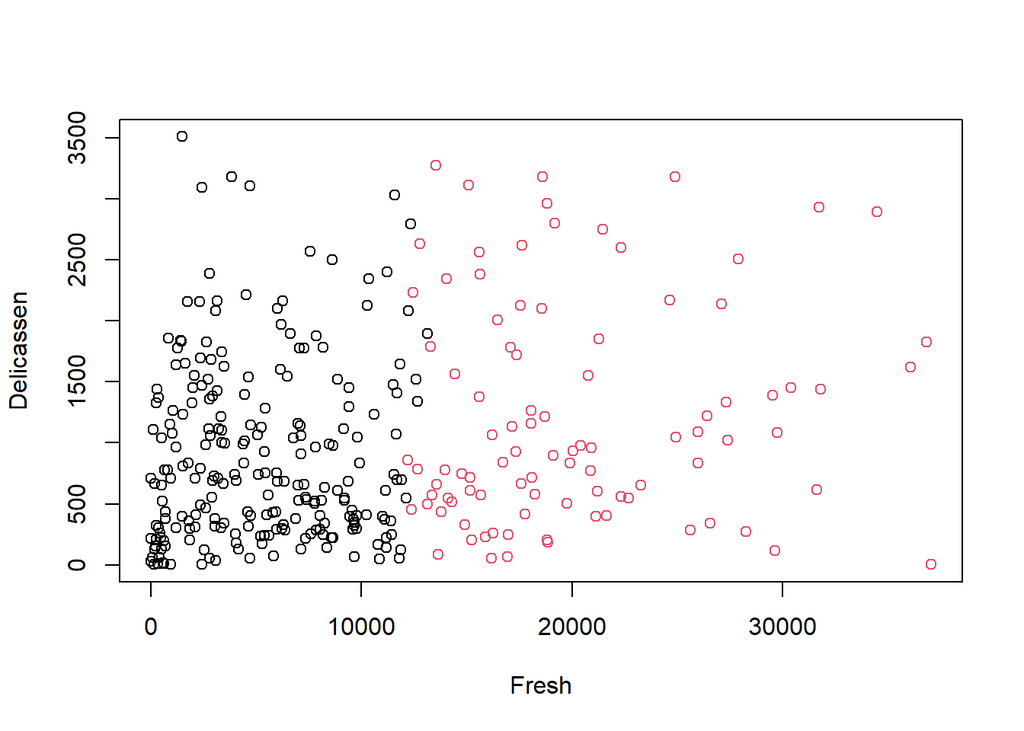

```r
 # Fresh y Delicassen
 plot(customers_data2[c(3,8)], col=k2$cluster)
```

como primer método se usará Hierarchical clustering el cual agrupa los datos basándose en la distancia entre cada uno de los datos. Con este método no es necesario indicar el número de clusters ya que lo hace de manera jerarquica

```r
#Definición del Hierarchical clustering con método de aglomeración completo. Conexión completa: La distancia se mide entre los dos puntos más lejanos de cada clúster
cluster_hc <- hclust(d = dist(x = customers_data_scale, method = "euclidean"),
                               method = "complete")
cluster_hc
```

```
##
## Call:
## hclust(d = dist(x = customers_data_scale, method = "euclidean"),     method = "complete")
##
## Cluster method   : complete
## Distance         : euclidean
## Number of objects: 323
```

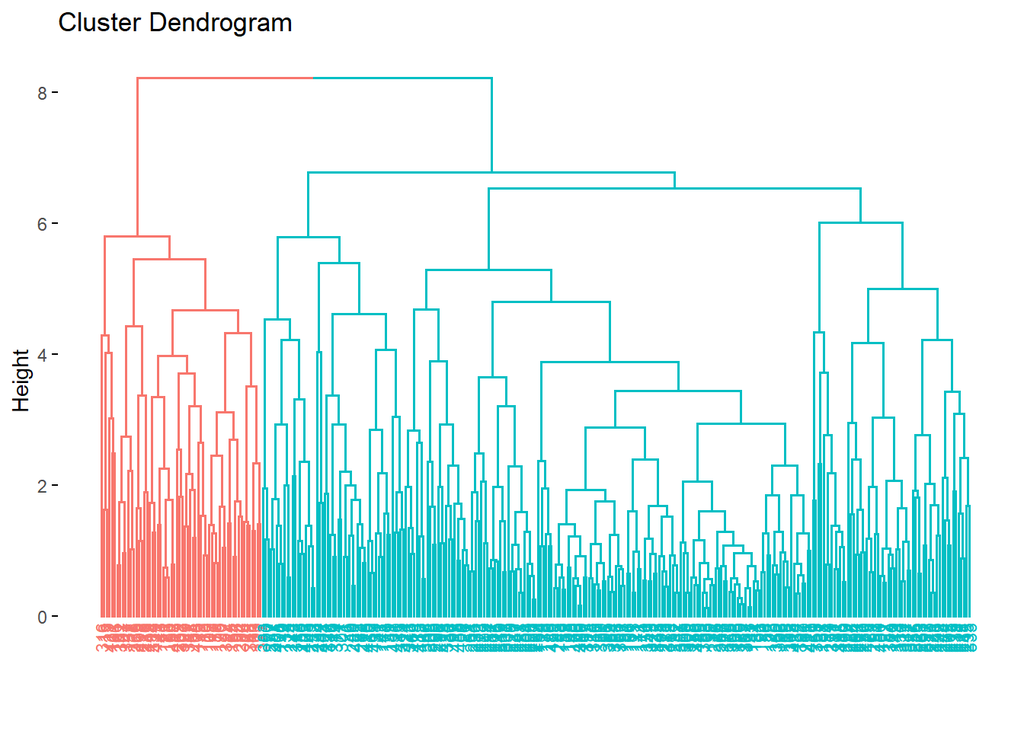

```r
#Se grafica el cluster definido
fviz_dend(x = cluster_hc, k = 2, cex = 0.6)
```

> Usando el Método K-medoids clustering - Partitioning Around Medoids (PAM)

Este método es parecido al K-Means la diferencia es que, en K-medoids, cada cluster está representado por una observación presente en el cluster (medoid), mientras que en K-means cada cluster está representado por su centroide, que se corresponde con el promedio de todas las observaciones del cluster pero con ninguna en particular.

medoid es: elemento dentro de un cluster cuya distancia (diferencia) promedio entre él y todos los demás elementos del mismo cluster es lo menor posible

El hecho de utilizar medoids en lugar de centroides hace de K-medoids un método más robusto que K-means, viéndose menos afectado por outliers o ruido.

```r
#Se genera el cluster PAM con 2
cluster_pam <- pam(x = customers_data2, k = 2, metric = "manhattan")
cluster_pam
```

[output not shown]

[output cut: 31 more lines]

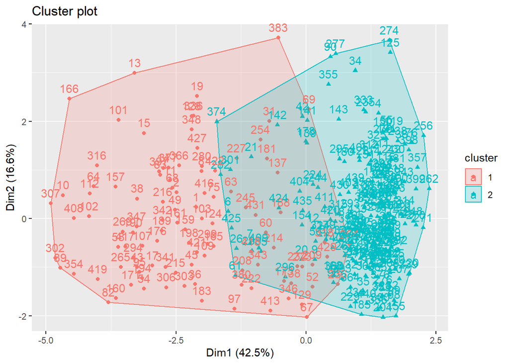

```r
#Se grafica el cluster definido
fviz_cluster(object = cluster_pam, data = customers_data_scale)
```

```r
#Descripción de los dos clusters
k2
```

```
## K-means clustering with 2 clusters of sizes 228, 95
##
## Cluster means:
##    Channel   Region     Fresh     Milk  Grocery   Frozen Detergents_Paper
## 1 1.307018 2.561404  5283.417 4335.754 6031.583 1682.211         2198.873
## 2 1.210526 2.547368 20168.853 3512.474 4959.232 2111.758         1189.158
##   Delicassen
## 1   893.0965
## 2  1218.3684
##
## Clustering vector:
##   1   2   4   6   7   8   9  10  11  12  13  14  15  16  17  19  20  21  22  26
##   1   1   2   1   1   1   1   1   1   2   2   2   2   1   1   2   1   2   1   2
##  27  28  31  32  33  34  35  36  38  39  42  43  45  49  51  52  54  55  56  58
##   1   2   2   1   2   2   1   1   2   1   2   1   1   1   1   1   1   2   1   1
```

[output cut: 39 more lines]

# 5 Resolución del problema. A partir de los resultados obtenidos, ¿cuáles son las conclusiones? ¿Los resultados permiten responder al problema?

Respecto a las graficas presentadas anteriormente y los datos arrojados por cada cluster podría definir dos asociaciones:

1. Clientes con preferencias por productos frescos.
2. Clientes sin preferencias definidas.

Ahora se mira detalladamente la información de los dos clusters

Se puede concluir que la variable Fresh es la que más diferencia presenta entre el cluster 1 y 2 ya que para el 1 su media es 5283.417 y para el 2 es 20168.853 y una diferencia más pequeña para la variable Delicassen 893.0965 y 1218.3684 respectivamente.

Adicionalmente tenemos una medida de suma de cuadrados del 42% la cual no es muy buena ya que son pocas las variables que hacen una clara discriminación entre los clusters.

```r
#Generación del archivo csv con la limpieza de datos

write.csv(customers_data2, file="Wholesale customers data2.csv")
```

# 6 referencias:

Calvo M, Subirats L, Pérez D (2019). Introducción a la limpieza y análisis de los datos. Editorial UOC.

Squire, Megan (2015). Clean Data. Packt Publishing Ltd.